# 2.7 Simple models

Jan Smyčka

20/01/2025

# The rethinking package

The R package for defining Bayesian models as Directed Acyclic Graphs (DAGs). DAG is a representation of our idea about how the data emerged in the real world, containing deterministic and stochastic processes.

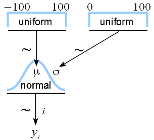

## Model definition

```r
gaussmodel<-alist(
  #model
  y~dnorm(mu, sigma),
  #priors
  mu~dunif(-100,100),
  sigma~dunif(0,100)
)
```

# t-test example

So let’s generate the data. We have ten boys drawn from a normal distribution with $\mu$=160, and ten girls drawn from a normal distribution with $\mu$=140. Both normal distributions have standard deviation 10.

```r
heightgirls=rnorm(10, 140, 10)
heightboys=rnorm(10, 160, 10)
```

This is a typical example of data that can be explored using frequentist t-test.

```r
t.test(heightgirls,heightboys, var.equal=F)
```

```
##
##  Welch Two Sample t-test
##
## data:  heightgirls and heightboys
## t = -6.5234, df = 17.852, p-value = 4.091e-06
## alternative hypothesis: true difference in means is not equal to 0
## 95 percent confidence interval:
##  -35.24482 -18.06559
## sample estimates:
## mean of x mean of y
##  136.8707  163.5259
```

```r
ttestmodel=alist(
  #likelihood
  heightgirls~dnorm(mugirls, sigma),
  heightboys~dnorm(muboys, sigma),
  #priors
  mugirls~dunif(100,200),
  muboys~dunif(100,200),
  sigma~dunif(0,1000)

)
```

Let’s now release the Hamiltonian Monte Carlo.

```r
ttestposterior=ulam(ttestmodel,
                    data=list(heightgirls=heightgirls, heightboys=heightboys))
```

```
## Running MCMC with 1 chain, with 1 thread(s) per chain...
##
## Chain 1 Iteration:   1 / 1000 [  0%]  (Warmup)
## Chain 1 Iteration: 100 / 1000 [ 10%]  (Warmup)
## Chain 1 Iteration: 200 / 1000 [ 20%]  (Warmup)
## Chain 1 Iteration: 300 / 1000 [ 30%]  (Warmup)
## Chain 1 Iteration: 400 / 1000 [ 40%]  (Warmup)
## Chain 1 Iteration: 500 / 1000 [ 50%]  (Warmup)
## Chain 1 Iteration: 501 / 1000 [ 50%]  (Sampling)
## Chain 1 Iteration: 600 / 1000 [ 60%]  (Sampling)
## Chain 1 Iteration: 700 / 1000 [ 70%]  (Sampling)
## Chain 1 Iteration: 800 / 1000 [ 80%]  (Sampling)
## Chain 1 Iteration: 900 / 1000 [ 90%]  (Sampling)
## Chain 1 Iteration: 1000 / 1000 [100%]  (Sampling)
## Chain 1 finished in 0.0 seconds.
```

Posterior estimates look like this. Neff>200 and Rhat>=1 suggest reasonable convergence.

```r
precis(ttestposterior)
```

```
##               mean       sd       5.5%    94.5%     rhat ess_bulk
## mugirls 136.556800 3.270371 131.275950 141.3332 1.010852 488.1720
## muboys  163.594844 3.245728 158.755205 169.0943 1.008486 495.1575
## sigma     9.921416 1.982942   7.237114  13.2936 1.006230 352.4928
```

We can also plot the results.

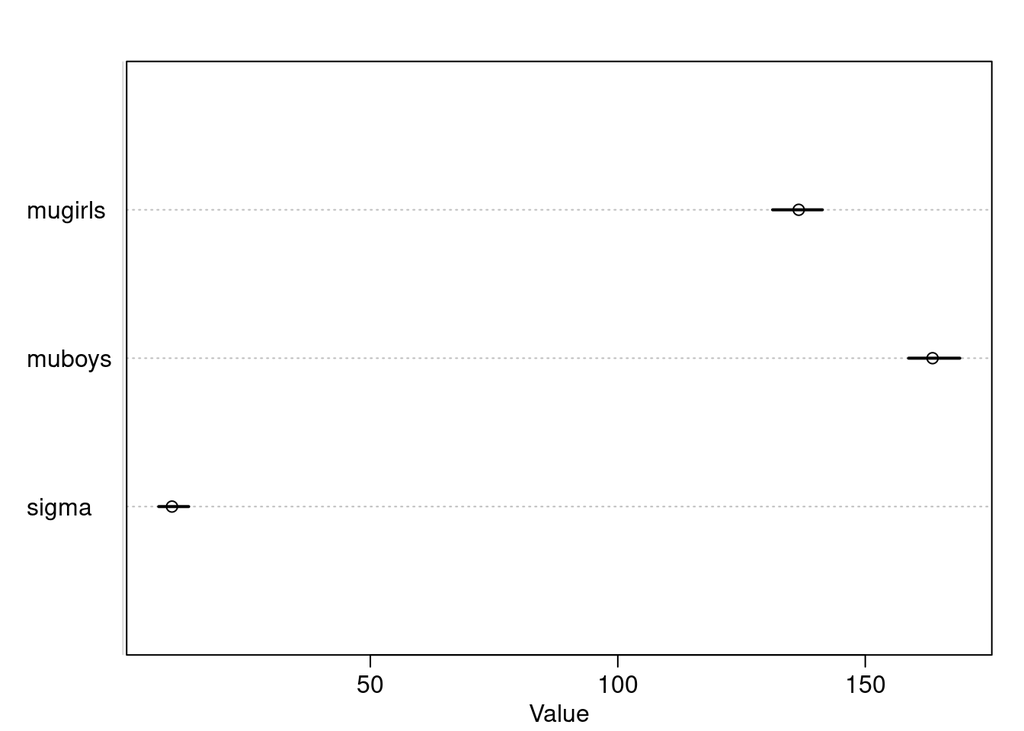

```r
plot(ttestposterior)
```

And explore if the chains converged visually. There should not be any trend in the chains and they should resemble the white noise.

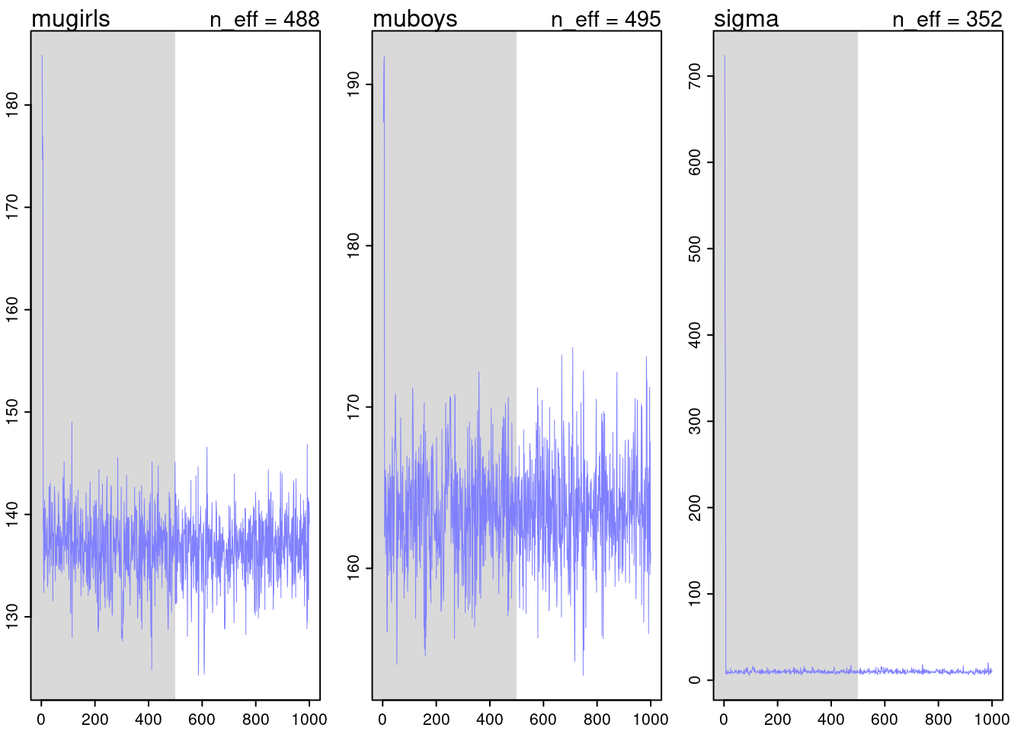

```r
traceplot(ttestposterior)
```

Apart from estimating most probable mean values for boys and girls, we can also explore whether these mean values are far enough to assume that boys and girl heights were not drawn from the same distribution. This is a Bayesian equivalent for t-test. To do this, we first need to extract the raw values from HMC chains.

```r
girlsposterior=extract.samples(ttestposterior)$mugirls
girlsposterior[1:10]
```

```
##  [1] 131.227 142.027 135.070 131.337 131.449 140.846 139.454 134.464 138.489
## [10] 136.893
```

```r
boysposterior=extract.samples(ttestposterior)$muboys
boysposterior[1:10]
```

```
##  [1] 160.864 165.629 162.201 164.639 164.490 165.724 165.589 162.017 167.590
## [10] 159.205
```

Cool thing about these chain posteriors is that we can do “intuitive mathematics” with them. So the posterior difference between boy and girls $\mu$s is just the difference between posterior vectors. We can see that this girls-boys difference is very likely not 0, so the boys and girls were drawn from distributions with different $\mu$.

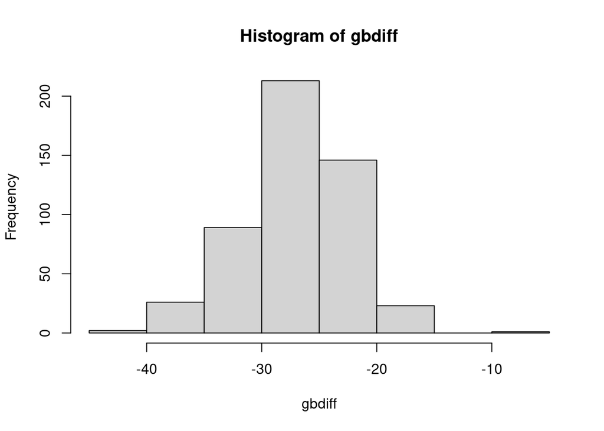

```r
gbdiff=girlsposterior-boysposterior
hist(gbdiff)
```

## Exercise 1

Make heteroskedastic t-test and test if variances differ between the groups.

```r
heightgirlsvar=rnorm(10, 140, 20)
heightboysvar=rnorm(10, 160, 5)
```

## Exercise 2

What happens if we put restrictive priors, e.g. dunif(150,200) for both boys and girls?

# Linear regression

The classical univariate linear regression model is formulated so that the expected value of response variable y is a linear function of predictor variable x. With stochastic component included it means that the observed values of y are a linear function of x with some normally distributed jitter added around. Distributivity of normal distribution also means that we can say y is drawn from normal distributions whose means are defined as a linear function of x. Typically we are interested in estimating the value of parameter $\beta$ from the linear function, when it is away from 0, it means that x values influence values of y.

$y_{exp}$ = $\alpha$ + $\beta$ * x

y = $\alpha$ + $\beta$ * x + norm( 0, $\sigma$ ) = norm( $\alpha$ + $\beta$ * x, $\sigma$ )

Let’s generate the data this way.

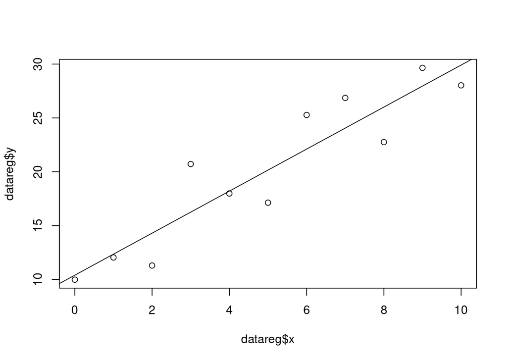

```r
datareg=data.frame(x=seq(0,10,by=1))
alpha=10
beta=2
sigma=3
datareg$y=rnorm(11,alpha+beta*datareg$x,sigma)
plot(datareg$y~datareg$x)
abline(lm(datareg$y~datareg$x))
```

The model definition is quite similar to t-test. The only new component is the definition of $y_{exp}$ , that is deterministically defined as a linear function f x. Note that “<-” operator stands for deterministic attribution, whereas “~” stands for stochastic attribution.

```r
regresmodel=alist(
  #likelihood
  y~dnorm(yexp, sigma),
  yexp <- alpha+beta*x,
  #priors
  alpha~dnorm(0,100),
  beta~dnorm(0,100),
  sigma~dunif(0 , 100)

)
```

Let’s run the HMC over the model.

```r
regresposterior=ulam(regresmodel,
                    data=list(x=datareg$x, y=datareg$y))
```

```
## Running MCMC with 1 chain, with 1 thread(s) per chain...
##
## Chain 1 Iteration:   1 / 1000 [  0%]  (Warmup)
## Chain 1 Iteration: 100 / 1000 [ 10%]  (Warmup)
## Chain 1 Iteration: 200 / 1000 [ 20%]  (Warmup)
## Chain 1 Iteration: 300 / 1000 [ 30%]  (Warmup)
## Chain 1 Iteration: 400 / 1000 [ 40%]  (Warmup)
## Chain 1 Iteration: 500 / 1000 [ 50%]  (Warmup)
## Chain 1 Iteration: 501 / 1000 [ 50%]  (Sampling)
## Chain 1 Iteration: 600 / 1000 [ 60%]  (Sampling)
## Chain 1 Iteration: 700 / 1000 [ 70%]  (Sampling)
## Chain 1 Iteration: 800 / 1000 [ 80%]  (Sampling)
## Chain 1 Iteration: 900 / 1000 [ 90%]  (Sampling)
## Chain 1 Iteration: 1000 / 1000 [100%]  (Sampling)
## Chain 1 finished in 0.0 seconds.
```

And explore the convergence.

```r
precis(regresposterior)
```

```
##            mean        sd     5.5%     94.5%      rhat ess_bulk
## alpha 10.055480 1.8469762 6.881941 12.882665 0.9986257 234.5216
## beta   1.995679 0.3157389 1.520080  2.511418 1.0008726 241.4033
## sigma  3.316824 0.9780568 2.151857  5.088894 1.0049249 112.4775
```

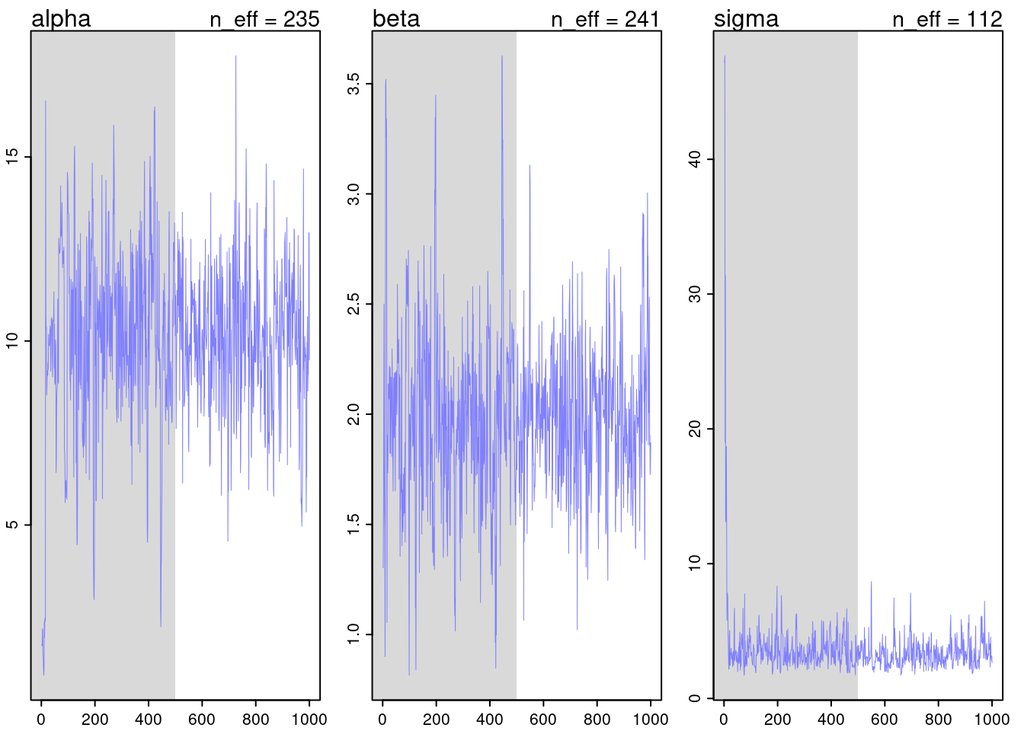

```r
traceplot(regresposterior)
```

For presenting the results of linear regression it is useful to plot the data as a scatterplot, and overlay them with mean posterior estimate of $y_{exp}$ and credibility band. We can use function link() to extract the $y_{exp}$ posterior.

```r
yexpregression=link(regresposterior)
dim(yexpregression)
```

```
## [1] 500  11
```

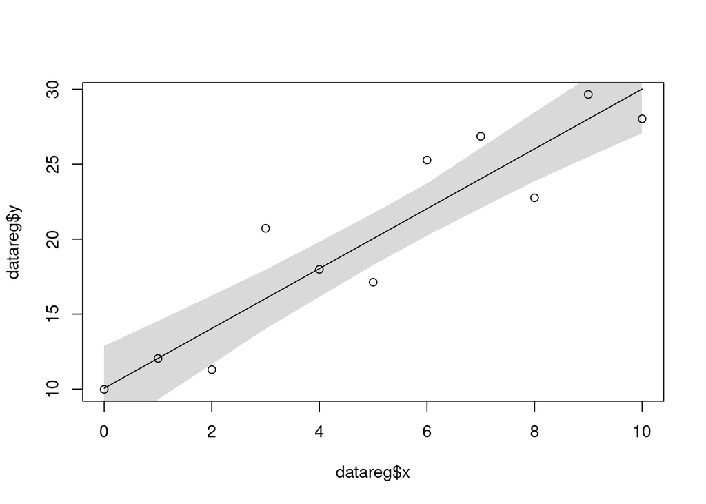

```r
yexpmeanregression=apply(yexpregression,2, mean)
yexpPIregression=apply(yexpregression,2, PI)

plot(datareg$y~datareg$x)
lines(datareg$x , yexpmeanregression)
shade(yexpPIregression , datareg$x)
```

## Exercise 3

Analyze and interpret the t-test data using the linear regression model. What is the relationship between muboys, mugirls, gbdiff, alpha and beta?

## Exercise 4

Make heteroskedastic regression, i.e. morel taking in account that variance is dependent on the predictor. Here are the data.

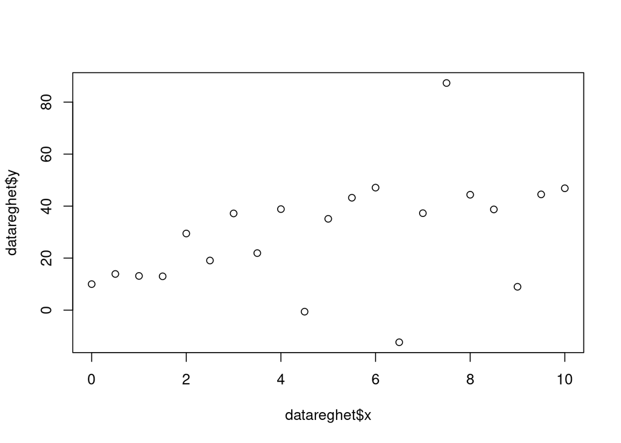

```r
datareghet=data.frame(x=seq(0,10,by=0.5))
alpha=10
beta=5
sigma=3
datareghet$y=rnorm(21,alpha+beta*datareghet$x,sigma*datareghet$x)
plot(datareghet$y~datareghet$x)
```

## Exercise 5

Make regression with two predictors. Here are the data.

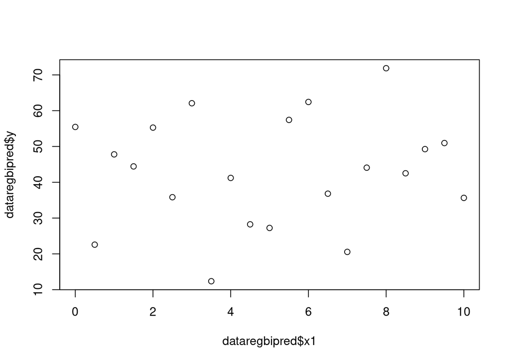

```r
dataregbipred=data.frame(x1=seq(0,10,by=0.5), x2=sample(seq(0,10,by=0.5),21, replace = F))
alpha=10
beta1=2
beta2=4
sigma=10
dataregbipred$y=rnorm(21,alpha+beta1*dataregbipred$x1+beta2*dataregbipred$x2,sigma)
plot(dataregbipred$y~dataregbipred$x1)
```

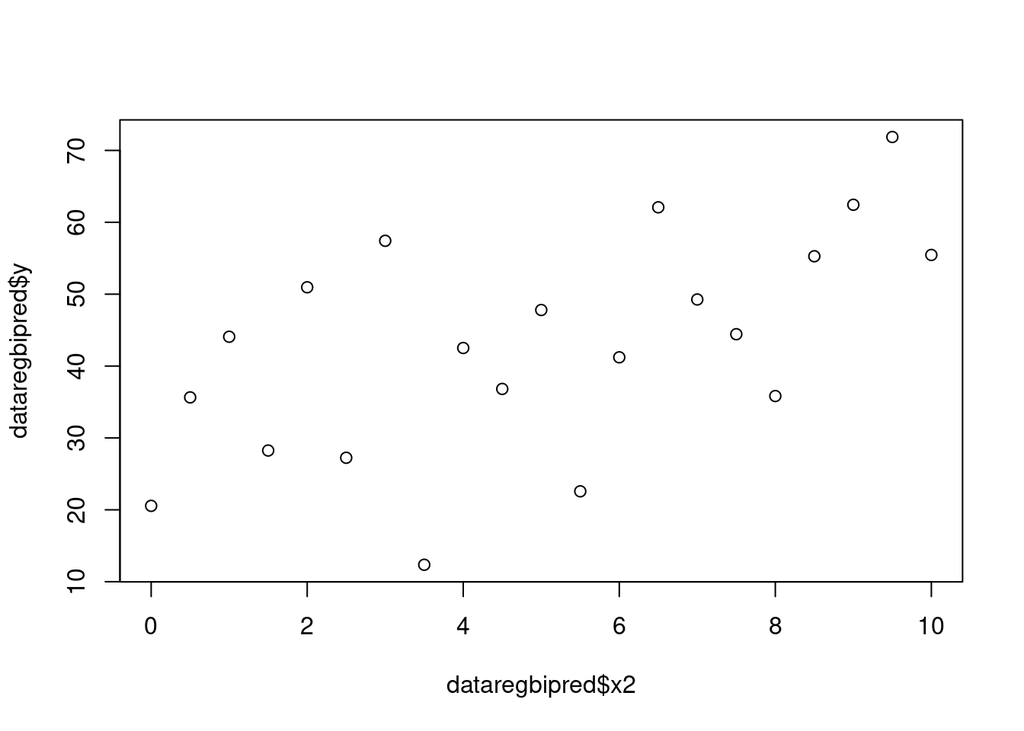

```r
plot(dataregbipred$y~dataregbipred$x2)
```

## Exercise 6

Make regression with two response variables. Here are the data. What is the difference against analyzing both response variables separately? How could we solve it if the stochastic components of y1 and y2 were not independent?

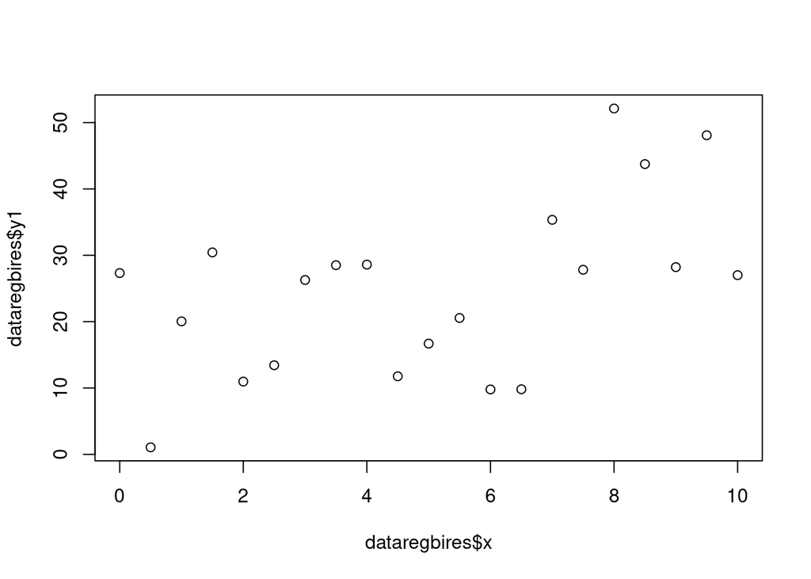

```r
dataregbires=data.frame(x=seq(0,10,by=0.5))
alpha=10
beta1=2
beta2=4
sigma=10
dataregbires$y1=rnorm(21,alpha+beta1*dataregbires$x,sigma)
dataregbires$y2=rnorm(21,alpha+beta2*dataregbires$x,sigma)

plot(dataregbires$y1~dataregbires$x)
```

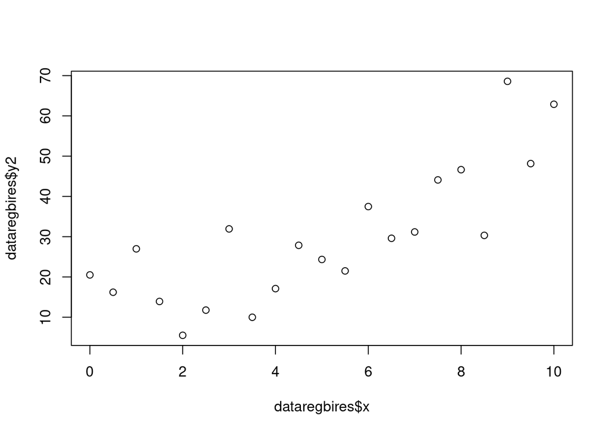

```r
plot(dataregbires$y2~dataregbires$x)
```